# Data Analysis for Researchers 2023, Week 4

2024/01/17

## Part I: EDA with WDI

## Week Three Review

- WDI package
  - WDI() for importing, WDIcache for updating meta data, WDIsearch for searching and getting data information
- Transforming data
  - select, filter, drop_na, distinct, group_by, summarize
- Visualizing data
  - line graph, scatterplot, histogram, boxplot, bar and column plot

### Week Three Assignment - Responses

- Week Three Assignment Template [[Link](https://ds-sl.github.io/intro2r/da4r/w3_assignment_template.nb.html)], [Rmd]
- Responses to Week Three Assignment [[Link](https://ds-sl.github.io/intro2r/da4r/w3a_response.nb.html)]

## Preview

- Week 4, Jan. 17: EDA3, WDI, tidy data (long and wide data), choropleth maps
- Week 5, Jan. 24: EDA4, UN, OECD, readr, readxl, two table verbes, modeling
- Week 6, Jan. 31: EDA5, Round-up, communication, pdf, Word, PowerPoint

## A short introduction to EDA workflow

1. Start RStudio
2. Create or open a project
   - File > Open Project or File > Recent Projects (or File > New Project)
3. R Notebook, R Markdown, Cuarto (or R Script, Console)
   - Reproducibility, Literate Programming and for Communication
   - R Notebook: HTML file with R Markdown source file

## Examples

- Purchasing power parities (PPPs) [[Link](https://ds-sl.github.io/intro2r/da4r/gdp_ppp.nb.html)], [Rmd]
- Life Expectancy [[Link](https://ds-sl.github.io/intro2r/da4r/life_expectancy.nb.html)], [Rmd]
- EDA using WDI: CO<sub>2</sub> Emissions Per Capita vs GDP Per Capita [[Link](https://ds-sl.github.io/intro2r/da4r/co2pcap.nb.html)], [Rmd]
- Education [[Link](https://ds-sl.github.io/intro2r/da4r/education.nb.html)], [Rmd]

## EDA Workflow with WDI

Start RStudio and open your project.

### Setup

```r
library(tidyverse)
library(WDI)
```

### WDIcache() [[Link in da4r](https://icu-hsuzuki.github.io/da4r/wdidata.html?q=WDIcache#wdicache)]

```r
wdicache <- WDIcache()
```

```r
str(wdicache, max.level = 1)
```

```
## List of 2
##  $ series :'data.frame': 24460 obs. of  5 variables:
##  $ country:'data.frame': 297 obs. of  9 variables:
```

- wdicache$series - WDI and other database
- wdicache$country - data about countries, list of countries, regions, income, lending, etc.

### WDI(…, extra=TRUE, cache=wdicache)

Download data with extra *updated* information

```
df_yourdata <- WDI(
  indicator = c(short_name_1 = chosen_indicator_1,
                short_name_2 = chosen_indicator_2),
  extra = TRUE, cache = wdicache)
```

### WDIsearch() [[Link in da4r](https://icu-hsuzuki.github.io/da4r/a3resp.html?q=WDIsearch#wdisearch)]

```
WDIsearch(string = "education", field = "name")
```

`short=FALSE`: description and source information `cache=wdicache`: updated information

```
WDIsearch(string = "school enrollment", field = "name", short = FALSE, cache = wdicache)
```

```
WDIsearch(string = "SE.XPD.TOTL.GD.ZS", field = "indicator", short = FALSE, cache = wdicache)
```

```r
WDIsearch(string = "(% of land area)", field = "name", short = FALSE, cache = wdicache)
```

|  | indicator | name | description | sourceDatabase | sourceOrganization |
| --- | --- | --- | --- | --- | --- |
| 1078 | AG.LND.AGRI.ZS | Agricultural land (% of land area) | Agricultural land refers to the share of land area that is arable, under permanent crops, and under permanent pastures. Arable land includes land defined by the FAO as land under temporary crops (doub… | World Development Indicators | Food and Agriculture Organization, electronic files and web site. |
| 1081 | AG.LND.ARBL.ZS | Arable land (% of land area) | Arable land includes land defined by the FAO as land under temporary crops (double-cropped areas are counted once), temporary meadows for mowing or for pasture, land under market or kitchen gardens, a… | World Development Indicators | Food and Agriculture Organization, electronic files and web site. |
| 1083 | AG.LND.CERE.ZS | Cereal cropland (% of land area) | Land under cereal production refers to harvested area, although some countries report only sown or cultivated area. Cereals include wheat, rice, maize, barley, oats, rye, millet, sorghum, buckwheat, a… | Africa Development Indicators | Food and Agriculture Organization, Production Yearbook and data files. |
| 1086 | AG.LND.CROP.ZS | Permanent cropland (% of land area) | Permanent cropland is land cultivated with crops that occupy the land for long periods and need not be replanted after each harvest, such as cocoa, coffee, and rubber. This category includes land unde… | World Development Indicators | Food and Agriculture Organization, electronic files and web site. |
| 1097 | AG.LND.FRST.ZS | Forest area (% of land area) | Forest area is land under natural or planted stands of trees of at least 5 meters in situ, whether productive or not, and excludes tree stands in agricultural production systems (for example, in fruit… | World Development Indicators | Food and Agriculture Organization, electronic files and web site. |
| 1105 | AG.LND.OTHR.ZS | Land use, other (% of land area) |  | WDI Database Archives |  |
| 1107 | AG.LND.PPAS.ZS | Permanent pasture (% of land area) |  | WDI Database Archives |  |
| 6289 | EN.LAND.CRP.ZS | Land use, cropland (% of land area) |  | WDI Database Archives |  |
| 6291 | EN.LAND.OTH.ZS | Land use, other (% of land area) |  | WDI Database Archives |  |
| 6293 | EN.LAND.PPS.ZS | Land use, permanent pasture (% of land area) |  | WDI Database Archives |  |

```r
WDIsearch(string = "(hectares)", field = "name", short = FALSE, cache = wdicache)
```

|  | indicator | name | description | sourceDatabase | sourceOrganization |
| --- | --- | --- | --- | --- | --- |
| 1076 | AG.LND.AGRI.HA | Agricultural land (hectares) | Agricultural land refers to the share of land area that is arable, under permanent crops, and under permanent pastures. Arable land includes land defined by the FAO as land under temporary crops (doub… | Africa Development Indicators | Food and Agriculture Organization, electronic files and web site. |
| 1079 | AG.LND.ARBL.HA | Arable land (hectares) | Arable land (in hectares) includes land defined by the FAO as land under temporary crops (double-cropped areas are counted once), temporary meadows for mowing or for pasture, land under market or kitc… | World Development Indicators | Food and Agriculture Organization, electronic files and web site. |
| 1080 | AG.LND.ARBL.HA.PC | Arable land (hectares per person) | Arable land (hectares per person) includes land defined by the FAO as land under temporary crops (double-cropped areas are counted once), temporary meadows for mowing or for pasture, land under market… | World Development Indicators | Food and Agriculture Organization, electronic files and web site. |
| 1082 | AG.LND.BLY.HA | Land under barley production (hectares) | Land under barley production refers to harvested area, although some countries report only sown or cultivated area. Production data on relate to crop harvested for dry grain only. Crop harvested for h… | Africa Development Indicators | Food and Agriculture Organization, electronic files and web site. |
| 1084 | AG.LND.CREL.HA | Land under cereal production (hectares) | Land under cereal production refers to harvested area, although some countries report only sown or cultivated area. Cereals include wheat, rice, maize, barley, oats, rye, millet, sorghum, buckwheat, a… | World Development Indicators | Food and Agriculture Organization, electronic files and web site. |
| 1085 | AG.LND.CROP.HA | Permanent cropland (hectares) | Permanent cropland is land cultivated with crops that occupy the land for long periods and need not be replanted after each harvest, such as cocoa, coffee, and rubber. This category includes land unde… | Africa Development Indicators | Food and Agriculture Organization, electronic files and web site. |
| 1087 | AG.LND.CRPA.HA | Arable and permanent cropland (hectares) | This land category is the sum of areas under “Arable land” and "Permanent crops”. Arable land includes land defined by the FAO as land under temporary crops (double-cropped areas are counted once), te… | Africa Development Indicators | Food and Agriculture Organization, electronic files and web site. |
| 1093 | AG.LND.FNO.HA | Land under fonio production (hectares) | Land under fonio production refers to harvested area, although some countries report only sown or cultivated area. Production data on relate to crop harvested for dry grain only. Crop harvested for ha… | Africa Development Indicators | Food and Agriculture Organization, electronic files and web site. |
| 1094 | AG.LND.FRLS.HA | Tree Cover Loss (hectares) | Shows year-by-year tree cover loss, defined as stand level replacement of vegetation greater than 5 meters, within the selected area. The tree cover loss data set is a collaboration of the University … | Environment, Social and Governance (ESG) Data | Global Forest Watch. Tree Cover Loss (Hansen/UMD/Google/USGS/NASA). |
| 1095 | AG.LND.FRST.HA | Forest area (hectares) | Forest area is land under natural or planted stands of trees of at least 5 meters in situ, whether productive or not, and excludes tree stands in agricultural production systems (for example, in fruit… | Africa Development Indicators | Food and Agriculture Organization, electronic files and web site. |

[output cut: 24 more lines]

```r
WDIsearch(string = "(% of GDP)", field = "name", short = FALSE, cache = wdicache)
```

|  | indicator | name | description | sourceDatabase | sourceOrganization |
| --- | --- | --- | --- | --- | --- |
| 1609 | BG.GSR.NFSV.GD.ZS | Trade in services (% of GDP) | Trade in services is the sum of service exports and imports divided by the value of GDP, all in current U.S. dollars. | World Development Indicators | International Monetary Fund, Balance of Payments Statistics Yearbook and data files, and World Bank and OECD GDP estimates. |
| 1610 | BG.KAC.FNEI.GD.PP.ZS | Gross private capital flows (% of GDP, PPP) |  | WDI Database Archives |  |
| 1611 | BG.KAC.FNEI.GD.ZS | Gross private capital flows (% of GDP) |  | WDI Database Archives |  |
| 1612 | BG.KLT.DINV.GD.PP.ZS | Gross foreign direct investment (% of GDP, PPP) |  | WDI Database Archives |  |
| 1613 | BG.KLT.DINV.GD.ZS | Gross foreign direct investment (% of GDP) |  | WDI Database Archives |  |
| 1946 | BM.KLT.DINV.GD.ZS | Foreign direct investment, net outflows (% of GDP) | Foreign direct investment are the net inflows of investment to acquire a lasting management interest (10 percent or more of voting stock) in an enterprise operating in an economy other than that of th… | WDI Database Archives | International Monetary Fund, International Financial Statistics and Balance of Payments databases, World Bank, International Debt Statistics, and World Bank and OECD GDP estimates. |
| 1947 | BM.KLT.DINV.WD.GD.ZS | Foreign direct investment, net outflows (% of GDP) | Foreign direct investment refers to direct investment equity flows in an economy. It is the sum of equity capital, reinvestment of earnings, and other capital. Direct investment is a category of cross… | World Development Indicators | International Monetary Fund, Balance of Payments database, supplemented by data from the United Nations Conference on Trade and Development and official national sources. |
| 1960 | BN.CAB.XOKA.GD.ZS | Current account balance (% of GDP) | Current account balance is the sum of net exports of goods and services, net primary income, and net secondary income. | World Development Indicators | International Monetary Fund, Balance of Payments Statistics Yearbook and data files, and World Bank and OECD GDP estimates. |
| 1961 | BN.CAB.XOKA.GDP.ZS | Current account balance (% of GDP) |  | WDI Database Archives |  |
| 1964 | BN.CAB.XOTR.ZS | Curr. acc. bal. before official transf. (% of GDP) |  | WDI Database Archives |  |

[output cut: 335 more lines]

```r
WDIsearch(string = "(% of population)", field = "name", short = FALSE, cache = wdicache)
```

|  | indicator | name | description | sourceDatabase | sourceOrganization |
| --- | --- | --- | --- | --- | --- |
| 1159 | allsa.cov_pop | Coverage of social safety net programs (% of population) |  | WDI Database Archives |  |
| 1162 | allsi.cov_pop | Coverage of social insurance programs (% of population) |  | WDI Database Archives |  |
| 1165 | allsp.cov_pop | Coverage of social protection and labor programs (% of population) |  | WDI Database Archives |  |
| 6162 | EG.CFT.ACCS.ZS | Access to clean fuels and technologies for cooking (% of population) | Access to clean fuels and technologies for cooking is the proportion of total population primarily using clean cooking fuels and technologies for cooking. Under WHO guidelines, kerosene is excluded fr… | World Development Indicators | IEA, IRENA, UNSD, World Bank, WHO. 2023. Tracking SDG 7: The Energy Progress Report. World Bank, Washington DC. © World Bank. License: Creative Commons Attribution—NonCommercial 3.0 IGO (CC BY-NC 3.0 … |
| 6167 | EG.ELC.ACCS.ZS | Access to electricity (% of population) | Access to electricity is the percentage of population with access to electricity. Electrification data are collected from industry, national surveys and international sources. | World Development Indicators | IEA, IRENA, UNSD, World Bank, WHO. 2023. Tracking SDG 7: The Energy Progress Report. World Bank, Washington DC. © World Bank. License: Creative Commons Attribution—NonCommercial 3.0 IGO (CC BY-NC 3.0 … |
| 6195 | EG.NSF.ACCS.ZS | Access to non-solid fuel (% of population) | Access to non-solid fuel is the percentage of population with access to non-solid fuel. | WDI Database Archives | World Bank, Sustainable Energy for All (SE4ALL) database from WHO Global Household Energy database. |
| 6269 | EN.CLC.MDAT.ZS | Droughts, floods, extreme temperatures (% of population, average 1990-2009) | Droughts, floods and extreme temperatures is the annual average percentage of the population that is affected by natural disasters classified as either droughts, floods, or extreme temperature events.… | World Development Indicators | EM-DAT: The OFDA/CRED International Disaster Database: www.emdat.be, Université Catholique de Louvain, Brussels (Belgium), World Bank. |
| 8073 | FX.OWN.TOTL.40.ZS | Account ownership at a financial institution or with a mobile-money-service provider, poorest 40% (% of population ages 15+) | Account denotes the percentage of respondents who report having an account (by themselves or together with someone else) at a bank or another type of financial institution or report personally using a… | World Development Indicators | Global Findex Database, World Bank (https://www.worldbank.org/en/publication/globalfindex). |
| 8074 | FX.OWN.TOTL.60.ZS | Account ownership at a financial institution or with a mobile-money-service provider, richest 60% (% of population ages 15+) | Account denotes the percentage of respondents who report having an account (by themselves or together with someone else) at a bank or another type of financial institution or report personally using a… | World Development Indicators | Global Findex Database, World Bank (https://www.worldbank.org/en/publication/globalfindex). |
| 8075 | FX.OWN.TOTL.FE.ZS | Account ownership at a financial institution or with a mobile-money-service provider, female (% of population ages 15+) | Account denotes the percentage of respondents who report having an account (by themselves or together with someone else) at a bank or another type of financial institution or report personally using a… | World Development Indicators | Global Findex Database, World Bank (https://www.worldbank.org/en/publication/globalfindex). |

[output cut: 193 more lines]

```r
WDIsearch(string = "XPD", field = "indicator", short = FALSE, cache = wdicache)
```

|  | indicator | name | description | sourceDatabase | sourceOrganization |
| --- | --- | --- | --- | --- | --- |
| 5586 | DT.ODA.ALLD.XPD.ZS | Aid (% of central government expenditures) |  | WDI Database Archives |  |
| 6142 | EC.XPD.CAP.CR | Capital expenditure (in IDR) |  | Indonesia Database for Policy and Economic Research |  |
| 6143 | EC.XPD.GSR.CR | Goods and services expenditure (in IDR) |  | Indonesia Database for Policy and Economic Research | Ministry of Finance, SIKD (Information System for Sub-National Budget) |
| 6144 | EC.XPD.OTHR.CR | Others expenditure (in IDR) |  | Indonesia Database for Policy and Economic Research | Ministry of Finance, SIKD (Information System for Sub-National Budget) |
| 6145 | EC.XPD.STAF.CR | Personnel expenditure (in IDR) |  | Indonesia Database for Policy and Economic Research | Ministry of Finance, SIKD (Information System for Sub-National Budget) |
| 6146 | EC.XPD.TOTL.CR | Total Expenditure (in IDR) |  | Indonesia Database for Policy and Economic Research | Ministry of Finance, SIKD (Information System for Sub-National Budget) |
| 6773 | FC.XPD.ADMN.CR | General administration function expenditure (in IDR) |  | Indonesia Database for Policy and Economic Research | Ministry of Finance, SIKD (Information System for Sub-National Budget) |
| 6774 | FC.XPD.AGR.CR | Agriculture function expenditure (in IDR) |  | Indonesia Database for Policy and Economic Research | Ministry of Finance, SIKD (Information System for Sub-National Budget) |
| 6775 | FC.XPD.ECON.CR | Economy function expenditure (in IDR) |  | Indonesia Database for Policy and Economic Research | Ministry of Finance, SIKD (Information System for Sub-National Budget) |
| 6776 | FC.XPD.EDU.CR | Education function expenditure (in IDR) |  | Indonesia Database for Policy and Economic Research | Ministry of Finance, SIKD (Information System for Sub-National Budget) |

[output cut: 83 more lines]

### Data Importing

```
df_yourdata <- WDI(
  indicator = c(short_name_1 = chosen_indicator_1,
                short_name_2 = chosen_indicator_2),
  extra = TRUE, cache = wdicache)
```

```
df_lifeexp <- WDI(
  indicator = c(pop = "SP.POP.TOTL",
                fertility = "SP.DYN.TFRT.IN",
                lifeexp = "SP.DYN.LE00.IN"),
  extra = TRUE, cache = wdicache)
```

```
df_lifeexp <- WDI(
  indicator = c(pop = "SP.POP.TOTL",
                fertility = "SP.DYN.TFRT.IN",
                lifeexp = "SP.DYN.LE00.IN"))
```

### Data Transforming by `dplyr` and `tidyr` in `tidyverse`

- `select()` : select columns `select(c(1,2,4,5,7,8))`
- `filter()` : select rows meeting a condition
  - `filter(country == "World")`
  - `filter(iso2c %in% c("JP", "IN", "CN"))`
  - `filter(region != "Aggregates")`
- `distinct()` : select rows with distinct values of a variable `distinct(country)`
- `drop_na()` : drop rows with NA values, e.g. `drop_na(pop)`
- `arrange` , `mutate` , `group_by` and `summarize`

#### `arrange`, `mutate`, `group_by` and `summarize`

```
df_ed |> group_by(year) |>
  summarize(expenditure = sum(!is.na(expenditure)),
                                     primary = sum(!is.na(primary)),
                                     secondary = sum(!is.na(secondary)),
                                     tertiary = sum(!is.na(tertiary))) |>
  arrange(desc(year))
```

#### Long Data vs Wide Data [[r4ds tidyr](https://icu-hsuzuki.github.io/da4r/tidy.html?q=pivot_longer#tidy)]

```
df |> pivot_longer(cols = c(columns to gather))
```

```
df |> pivot_longer(cols = c(columns to gather), names_to = "name", values_to = "value")
```

### Data Visualizing by `ggplot` in `tidyverse`

- `ggplot(aes(x=var1, y=var2)) + geom_***()`
- Scatter Plot: `geom_point(aes(col=var3, size=var4, shape=var5))`
- Line Graph: `geom_line(aes(col=var3, linetype=var4)))`
- Histogram: `geom_histogram(bins = 20)`, `geom_histogram(binwidth = 5)`
  - What is a histogram? [[video](https://vimeo.com/221607341)]
- Boxplot: `geom_boxplot(aes(x = var4, y = var1, fill = var3))`
  - What is a boxplot? [[video](https://vimeo.com/222358034)]
- Title, Subtitle, Legend and Axis labels
  - `labs(title = "", subtitle ="", x = "", y = "", col = "")`

#### Choropleth Maps [[r4ds worldmap](https://icu-hsuzuki.github.io/da4r/worldmap.html#worldmap)]

rnaturalearth: [[CRAN](https://cran.r-project.org/web/packages/rnaturalearth/index.html)], [[Manual](https://cran.r-project.org/web/packages/rnaturalearth/rnaturalearth.pdf)], [[URL](https://www.naturalearthdata.com)], rnaturalearthdata: [[CRAN](https://cran.r-project.org/web/packages/rnaturalearthdata/index.html)], [[Manual](https://cran.r-project.org/web/packages/rnaturalearthdata/rnaturalearthdata.pdf)]

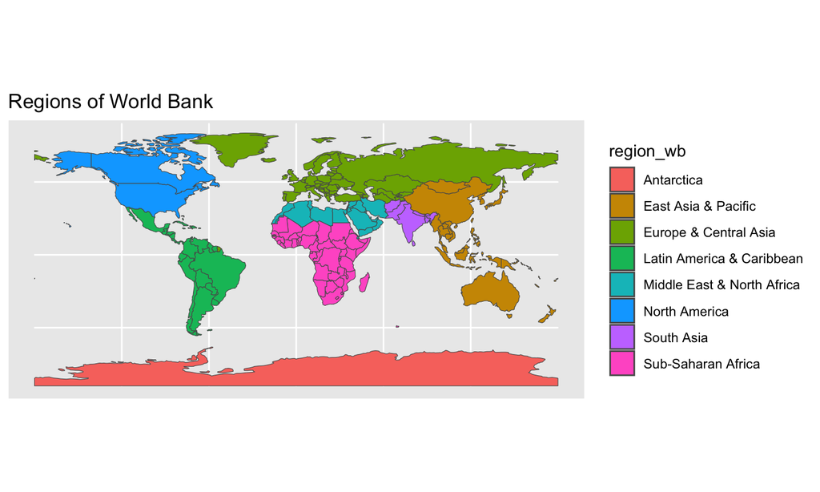

```r
library(rnaturalearth); library(rnaturalearthdata)
ne_countries() %>%
  ggplot() + geom_sf(aes(fill = region_wb)) + labs(title = "Regions of World Bank")
```

## Part II: Practicum

## Education

### World Development Indicators: Data themes [[Link](https://datatopics.worldbank.org/world-development-indicators/)]

- Data Catalog: World Development Indicators [[Link](https://datacatalog.worldbank.org/search/dataset/0037712/World-Development-Indicators)]
- The World by Income and Region [[Link](https://datatopics.worldbank.org/world-development-indicators/the-world-by-income-and-region.html)]
- World Bank Country and Lending Groups [[Link](https://datahelpdesk.worldbank.org/knowledgebase/articles/906519-world-bank-country-and-lending-groups)]
- People [[Link](https://datatopics.worldbank.org/world-development-indicators/themes/people.html)]
  - Government expenditure on education, total (% of GDP): SE.XPD.TOTL.GD.ZS [[Link](https://data.worldbank.org/indicator/SE.XPD.TOTL.GD.ZS)]
  - School enrollment, primary (% gross): SE.PRM.ENRR [[Link](https://data.worldbank.org/indicator/SE.PRM.ENRR)]
  - School enrollment, secondary (% gross): SE.SEC.ENRR [[Link](https://data.worldbank.org/indicator/SE.SEC.ENRR)]
  - School enrollment, tertiary (% gross): SE.TER.ENRR [[Link](https://data.worldbank.org/indicator/SE.TER.ENRR)]

### File Links

- Education [[Link](https://ds-sl.github.io/intro2r/da4r/education.nb.html)], [Rmd]
- Week Four Assignment Template [[Link](https://ds-sl.github.io/intro2r/da4r/w4_assignment_template.nb.html)], [Rmd]

## Week Four Assignment

Choose at least two *similar* WDI codes with the *same scale*, and analyze the data.

- Create an R Notebook of a data analysis containing the following and submit the rendered file (e.g., `w4_g123456.nb.html`) in Moodle.
  1. Create an R Notebook using the R Notebook Template in Moodle and save it as `w4_g123456.Rmd`.
  2. Edit author with name, ID, and title.
- Contents should include the following:
  - A short abstract
  - Information of data including data name, data code (or id), description
  - Data including at least two indicators and a long table created using `pivot_longer`
  - A line graph using the long table with a color aesthetic to depict at least two indicators in a chart.
  - Several charts: a bar graph or a column graph, a histogram, a line graph, a scatter plot
  - Observations or questions for visualizations
- Include a choropleth map, if possible. (a challenge, not required)
- Run each code block and preview to create `w4_g123456.nb.html`.
  - Or, Run All under Run and Preview to check in your web browser!
  - You can also view your file (e.g. `w4_g123456.nb.html`) by opening it from your web browser.

Submit your R Notebook file (w4_g123456.nb.html) in Moodle (Week Four Assignment).

*Due Sunday 21, January 2024, 11:59 PM*

## Recommended Readings and Activities

1. World Development Indicators: Data themes [[Link](https://datatopics.worldbank.org/world-development-indicators/)]
   - Find data you want to study. Record the name, WDI code, and possibly the URL.
2. Posit Recipes（New edition of Posit Primers）: interactive exercises [[Link](https://posit.cloud/learn/recipes)]
3. Data visualization with ggplot2. PDF is available on the top right. [[Site Link](https://rstudio.github.io/cheatsheets/html/data-visualization.html)]
4. Data transformation with dplyr. PDF is available on the top right. [[Site Link](https://rstudio.github.io/cheatsheets/html/data-transformation.html)]
5. Data tidying with tidyr. PDF is available on the top right. [[Site Link](https://rstudio.github.io/cheatsheets/html/tidyr.html)]